# Algoritmos

Rocio Gomez

2026-04-01

## Primeros comandos de R

R es un lenguaje muy parecido a matlab y trabaja especialmente con variables que en general pueden ser matrices.

```r
A=38
A=40
B=60
C=B-A
C
```

```
## [1] 20
```

##Uso de data sets o uso de bases de datos internos de R.

Si escribo en console data() se abre una serie de datos ya cargados en R que estan dados en tablas de las cuales podemos elegir columnas específicas si escribimos $ despues del comando de información específico.

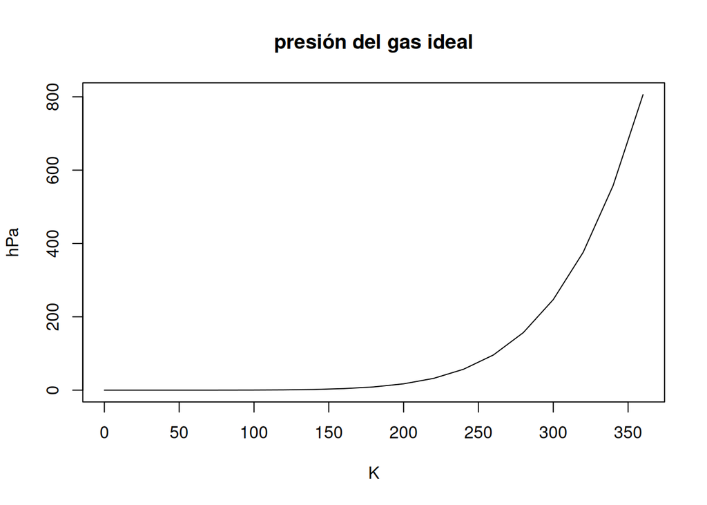

```r
plot(pressure,type="l" , main="presión del gas ideal", ylab="hPa",xlab="K")
```

##Comando Plot Comando que permite graficar cualquier fuente de datos que le asignemos, teniendo tambien la posibiidad de asignar nombres a las variables o hacer cambios al gráfico. En caso de no saber para que sirve un comando podemos escribir ?plot en la consola y se abrirá una pestaña que nos explicará.

##Funciones estadísticas

```r
z1<-rnorm(350,21,5)
```

```r
w1<-length(z1)
w1
```

```
## [1] 350
```

```r
x1<-(500:849)
x1
```

```
##   [1] 500 501 502 503 504 505 506 507 508 509 510 511 512 513 514 515 516 517
##  [19] 518 519 520 521 522 523 524 525 526 527 528 529 530 531 532 533 534 535
##  [37] 536 537 538 539 540 541 542 543 544 545 546 547 548 549 550 551 552 553
##  [55] 554 555 556 557 558 559 560 561 562 563 564 565 566 567 568 569 570 571
##  [73] 572 573 574 575 576 577 578 579 580 581 582 583 584 585 586 587 588 589
##  [91] 590 591 592 593 594 595 596 597 598 599 600 601 602 603 604 605 606 607
## [109] 608 609 610 611 612 613 614 615 616 617 618 619 620 621 622 623 624 625
## [127] 626 627 628 629 630 631 632 633 634 635 636 637 638 639 640 641 642 643
## [145] 644 645 646 647 648 649 650 651 652 653 654 655 656 657 658 659 660 661
## [163] 662 663 664 665 666 667 668 669 670 671 672 673 674 675 676 677 678 679
## [181] 680 681 682 683 684 685 686 687 688 689 690 691 692 693 694 695 696 697
## [199] 698 699 700 701 702 703 704 705 706 707 708 709 710 711 712 713 714 715
## [217] 716 717 718 719 720 721 722 723 724 725 726 727 728 729 730 731 732 733
## [235] 734 735 736 737 738 739 740 741 742 743 744 745 746 747 748 749 750 751
## [253] 752 753 754 755 756 757 758 759 760 761 762 763 764 765 766 767 768 769
## [271] 770 771 772 773 774 775 776 777 778 779 780 781 782 783 784 785 786 787
## [289] 788 789 790 791 792 793 794 795 796 797 798 799 800 801 802 803 804 805
## [307] 806 807 808 809 810 811 812 813 814 815 816 817 818 819 820 821 822 823
## [325] 824 825 826 827 828 829 830 831 832 833 834 835 836 837 838 839 840 841
## [343] 842 843 844 845 846 847 848 849
```

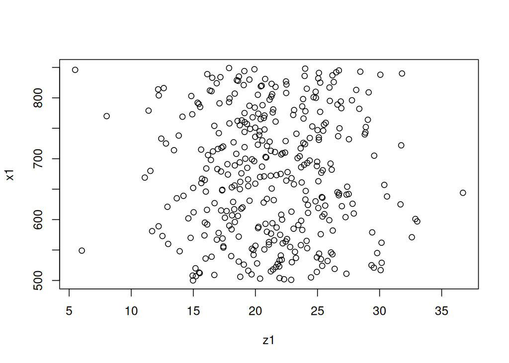

```r
plot(z1,x1) #comentario
```

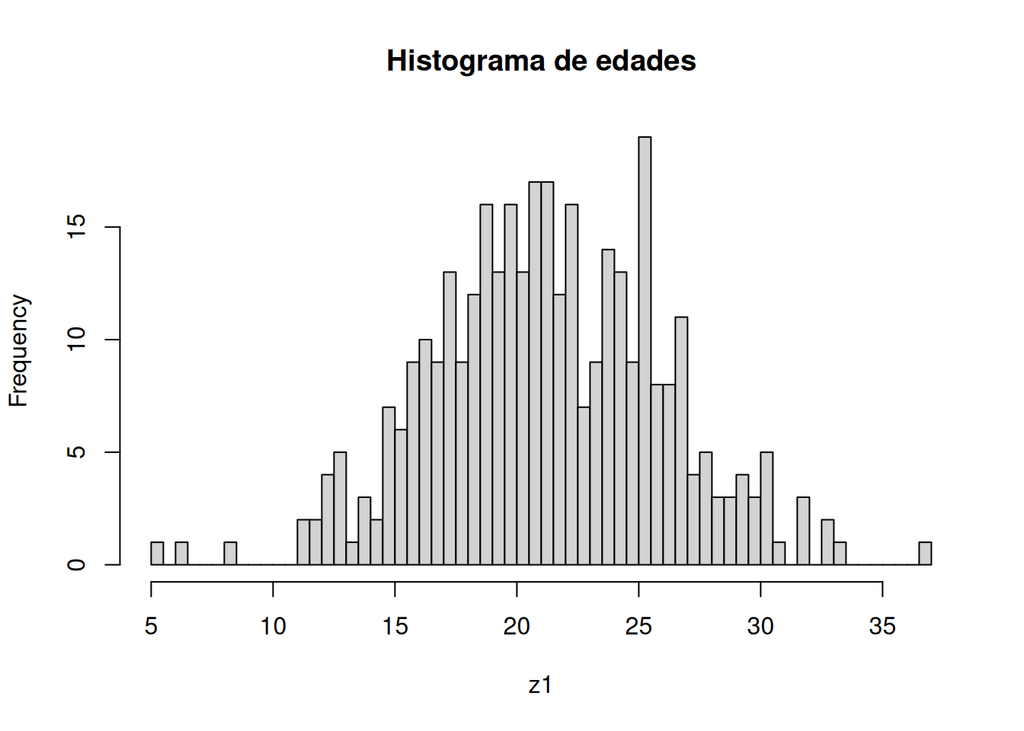

```r
hist(z1,main="Histograma de edades",breaks=50)
```

```r
density(z1,type="d")
```

```
##
## Call:
##  density.default(x = z1, type = "d")
##
## Data: z1 (350 obs.); Bandwidth 'bw' = 1.325
##
##        x                y
##  Min.   : 1.508   Min.   :9.641e-06
##  1st Qu.:11.302   1st Qu.:1.426e-03
##  Median :21.097   Median :1.096e-02
##  Mean   :21.097   Mean   :2.547e-02
##  3rd Qu.:30.892   3rd Qu.:5.227e-02
##  Max.   :40.686   Max.   :8.174e-02
```

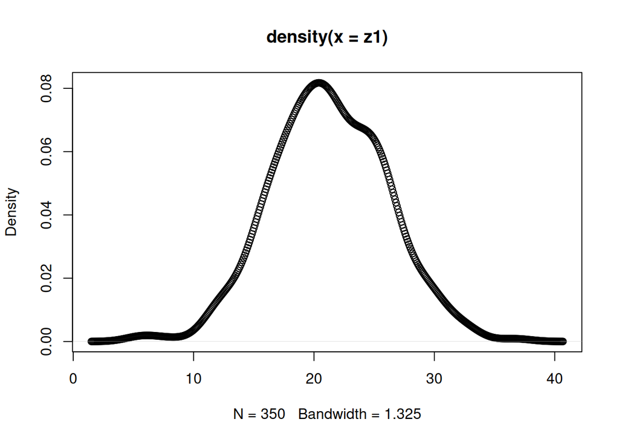

```r
plot(density(z1),type="b")
```

#Ejercicio 1 de algoritmoss

Consigna: Las últimas 3 cifras de mi DNI son 537 con estas crear una variable que tenga ese número

```r
dni=537
```

Consigna: Crear un vector que tenga todos los números enteros desde el 1 hasta el 537.

```r
secuenciadni<- (1:537)
secuenciadni
```

```
##   [1]   1   2   3   4   5   6   7   8   9  10  11  12  13  14  15  16  17  18
##  [19]  19  20  21  22  23  24  25  26  27  28  29  30  31  32  33  34  35  36
##  [37]  37  38  39  40  41  42  43  44  45  46  47  48  49  50  51  52  53  54
##  [55]  55  56  57  58  59  60  61  62  63  64  65  66  67  68  69  70  71  72
##  [73]  73  74  75  76  77  78  79  80  81  82  83  84  85  86  87  88  89  90
##  [91]  91  92  93  94  95  96  97  98  99 100 101 102 103 104 105 106 107 108
## [109] 109 110 111 112 113 114 115 116 117 118 119 120 121 122 123 124 125 126
## [127] 127 128 129 130 131 132 133 134 135 136 137 138 139 140 141 142 143 144
## [145] 145 146 147 148 149 150 151 152 153 154 155 156 157 158 159 160 161 162
## [163] 163 164 165 166 167 168 169 170 171 172 173 174 175 176 177 178 179 180
## [181] 181 182 183 184 185 186 187 188 189 190 191 192 193 194 195 196 197 198
## [199] 199 200 201 202 203 204 205 206 207 208 209 210 211 212 213 214 215 216
## [217] 217 218 219 220 221 222 223 224 225 226 227 228 229 230 231 232 233 234
## [235] 235 236 237 238 239 240 241 242 243 244 245 246 247 248 249 250 251 252
## [253] 253 254 255 256 257 258 259 260 261 262 263 264 265 266 267 268 269 270
## [271] 271 272 273 274 275 276 277 278 279 280 281 282 283 284 285 286 287 288
## [289] 289 290 291 292 293 294 295 296 297 298 299 300 301 302 303 304 305 306
## [307] 307 308 309 310 311 312 313 314 315 316 317 318 319 320 321 322 323 324
## [325] 325 326 327 328 329 330 331 332 333 334 335 336 337 338 339 340 341 342
## [343] 343 344 345 346 347 348 349 350 351 352 353 354 355 356 357 358 359 360
## [361] 361 362 363 364 365 366 367 368 369 370 371 372 373 374 375 376 377 378
## [379] 379 380 381 382 383 384 385 386 387 388 389 390 391 392 393 394 395 396
## [397] 397 398 399 400 401 402 403 404 405 406 407 408 409 410 411 412 413 414
## [415] 415 416 417 418 419 420 421 422 423 424 425 426 427 428 429 430 431 432
## [433] 433 434 435 436 437 438 439 440 441 442 443 444 445 446 447 448 449 450
## [451] 451 452 453 454 455 456 457 458 459 460 461 462 463 464 465 466 467 468
## [469] 469 470 471 472 473 474 475 476 477 478 479 480 481 482 483 484 485 486
## [487] 487 488 489 490 491 492 493 494 495 496 497 498 499 500 501 502 503 504
## [505] 505 506 507 508 509 510 511 512 513 514 515 516 517 518 519 520 521 522
## [523] 523 524 525 526 527 528 529 530 531 532 533 534 535 536 537
```

#Ejercicio 2: Calcular la suma de todos los valores del vector secuenciadni

```r
total<-0
valorfinal<-length(secuenciadni)
for(i in 1:valorfinal){
  total<-total+i
total}
```

#Ejercicio 3: Repetir el ejercicio anterior pero en phyton

```python
suma=0
for i in range (1,537):
  suma +=i

  print(suma)
```

```
## 1
## 3
## 6
## 10
## 15
## 21
## 28
## 36
## 45
## 55
## 66
## 78
## 91
## 105
## 120
## 136
## 153
## 171
## 190
## 210
## 231
## 253
## 276
## 300
## 325
## 351
## 378
## 406
## 435
## 465
## 496
## 528
## 561
## 595
## 630
## 666
## 703
## 741
## 780
## 820
```

[output cut: 481 more lines]

```
## 136503
## 137026
## 137550
## 138075
## 138601
## 139128
## 139656
## 140185
## 140715
## 141246
## 141778
## 142311
## 142845
## 143380
## 143916
```

#Ejercicio 4: ¿Cuánto tarda en correr el código del ejercicio 2?

```r
inicio<-Sys.time()
total<-0
valorfinal<-length(secuenciadni)
for(i in 1:valorfinal){
  total<-total+i
total}

final<-Sys.time()
final-inicio
```

```
## Time difference of 0.003486872 secs
```

#Ejercicio 5: Repetir el ejercicio anterior utilizando la cabeza de Gauss

```r
system.time({
  n <- length(secuenciadni)

  #Aplicamos la fórmula de Gauss
  total_gauss <- (n*(n+1))/2

  print(total_gauss)
})
```

```
## [1] 144453
```

```
##    user  system elapsed
##       0       0       0
```

PARTE DOS DE LOS EJERCICIOS

1.4 Generar un vector secuencia

```r
# --- 1. Generar secuencia con bucle 'for' ---
# Primero inicializamos el vector
system.time({
A <- 0
for (i in 1:50000) {
A[i] <- (i * 2)
}
})
```

```
##    user  system elapsed
##   0.010   0.002   0.012
```

```r
#Verificamos los resultados
head(A)
```

```
## [1]  2  4  6  8 10 12
```

```r
tail(A)
```

```
## [1]  99990  99992  99994  99996  99998 100000
```

```r
system.time({
B <- seq(from = 2, to = 100000, by = 2)
})
```

```
##    user  system elapsed
##       0       0       0
```

```r
# Verificamos los resultados
head(B)
```

```
## [1]  2  4  6  8 10 12
```

```r
tail(B)
```

```
## [1]  99990  99992  99994  99996  99998 100000
```

1.5 Implementación de una serie Fibonachi o Fibonacci

```r
# Definimos la cantidad de elementos de la serie que queremos calcular
n <- 30
# --- Método 1: Bucle 'for' con pre-asignación
system.time({
fib <- numeric(n)
fib[1] <- 0
fib[2] <- 1
for (i in 3:n) {
fib[i] <- fib[i-1] + fib[i-2]
}
})
```

```
##    user  system elapsed
##   0.004   0.000   0.003
```

```r
# Ver los primeros resultados
print("Primeros números de la serie:")
```

```
## [1] "Primeros números de la serie:"
```

```r
head(fib,10)
```

```
##  [1]  0  1  1  2  3  5  8 13 21 34
```

```r
# --- Método 2: Función Recursiva
fib_recursiva <- function(k) {
if (k == 0) return(0)
if (k == 1) return(1)
return(fib_recursiva(k - 1) + fib_recursiva(k - 2))
}
print("Tiempo ejecución recursiva:")
```

```
## [1] "Tiempo ejecución recursiva:"
```

```r
system.time({
# Calculamos el elemento n de forma individual
resultado_rec <- fib_recursiva(n)
})
```

```
##    user  system elapsed
##   0.775   0.001   0.784
```

1.6 Definición matemática recurrente

```r
# --- Resolver consigna con bucle 'while' ---
# Inicializamos la serie según la definición matemática
fib <- c(0, 1)
i <- 2 # Empezamos el conteo de iteraciones/posiciones
system.time({
# El bucle sigue mientras el último número generado sea <= 1.000.000
while (fib[i] <= 1000000) {
i <- i + 1
# Definición recurrente: f(n+1) = f(n) + f(n-1)
fib[i] <- fib[i-1] + fib[i-2]
}
})
```

```
##    user  system elapsed
##   0.004   0.000   0.003
```

```r
# --- Resultados ---
cat("El primer número mayor a 1.000.000 es:", fib[i], "\n")
```

```
## El primer número mayor a 1.000.000 es: 1346269
```

```r
cat("Se necesitaron", i - 1, "iteraciones (pasos) para superarlo.\n")
```

```
## Se necesitaron 31 iteraciones (pasos) para superarlo.
```

```r
# Mostramos los últimos elementos para verificar
tail(fib)
```

```
## [1]  121393  196418  317811  514229  832040 1346269
```

1.7 Ordenación de un vector por método burbuja

```r
# --- 1. Creamos un vector desordenado ---
# Usamos un vector de 1000 números aleatorios
set.seed(123) # Para que el resultado sea siempre el mismo
vector_desordenado <- sample(1:1000, 1000)
# --- 2. Implementación del Método Burbuja ---
bubble_sort <- function(x) {
n <- length(x)
# El bucle externo recorre todo el vector
for (i in 1:(n - 1)) {
# El bucle interno compara pares adyacentes
for (j in 1:(n - i)) {
if (x[j] > x[j + 1]) {
# Intercambio de posición (el "burbujeo")
temp <- x[j]
x[j] <- x[j + 1]
x[j + 1] <- temp
}
}
}
return(x)
}
# --- 3. Medimos Performance del Burbuja vs R Nativo ---
cat("Tiempo con Método Burbuja:\n")
```

```
## Tiempo con Método Burbuja:
```

```r
system.time({
vector_ordenado_burbuja <- bubble_sort(vector_desordenado)
})
```

```
##    user  system elapsed
##   0.059   0.000   0.059
```

```r
cat("\nTiempo con función sort() nativa de R:\n")
```

```
##
## Tiempo con función sort() nativa de R:
```

```r
system.time({
vector_ordenado_R <- sort(vector_desordenado)
})
```

```
##    user  system elapsed
##       0       0       0
```

1.8 La penitencia de Newton

```r
# Definimos el límite de la suma (1*10ˆ7 para que no tarde demasiado en R)
# Nota: 1*10ˆ10 es un número extremadamente grande para un bucle for en R
n <- 1e7
# --- MÉTODO 1: La "Penitencia" (Bucle For / Fuerza Bruta) ---
# Este método suma uno por uno, como quería el profesor.
system.time({
suma_iterativa <- 0
for (i in 1:n) {
suma_iterativa <- suma_iterativa + i
}
})
```

```
##    user  system elapsed
##   0.157   0.000   0.160
```

```r
cat("Resultado Suma Iterativa:", suma_iterativa, "\n")
```

```
## Resultado Suma Iterativa: 5e+13
```

```r
# --- MÉTODO 2: La "Estrategia de Newton/Gauss" (Fórmula Analítica) ---
# Usamos la suma de una progresión aritmética: (n * (n + 1)) / 2
system.time({
suma_analitica <- (n * (n + 1)) / 2
})
```

```
##    user  system elapsed
##       0       0       0
```

```r
cat("Resultado Suma Analítica:", suma_analitica, "\n")
```

```
## Resultado Suma Analítica: 5e+13
```

Gráficos de violín

```r
# 2.0 Comparación de Performance con Gráficos de Violín
# Instalamos y cargamos la librería necesaria
if(!require(microbenchmark)) install.packages("microbenchmark")
```

## Loading required package: microbenchmark

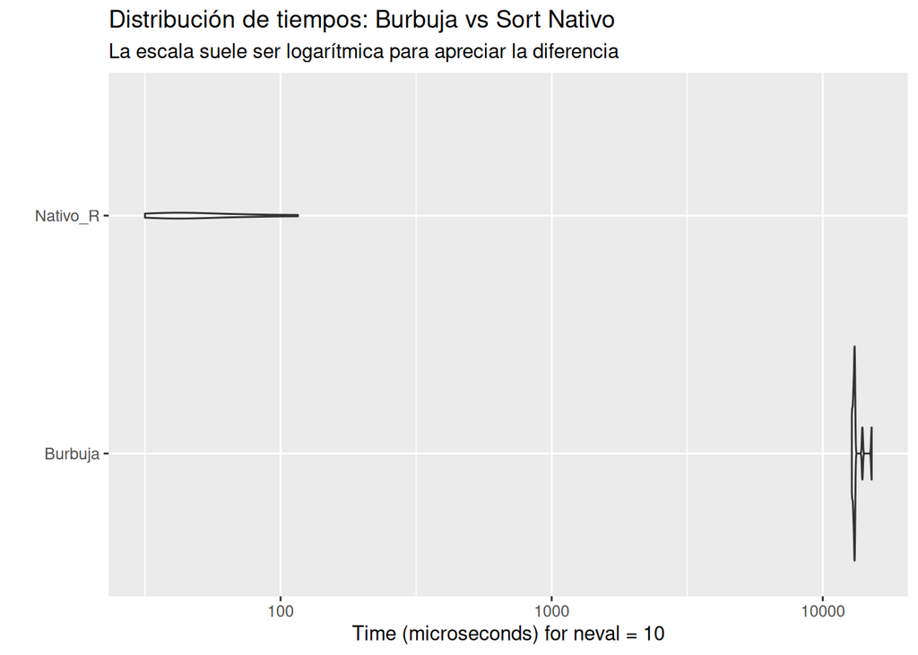

```r
if(!require(ggplot2)) install.packages("ggplot2")
library(microbenchmark)
library(ggplot2)
# --- 2.1 Comparación: Burbuja vs Sort Nativo ---
set.seed(123)
vector_prueba <- sample(1:500, 500)
# Usamos microbenchmark para ejecutar los métodos varias veces y comparar
comparativa_sort <- microbenchmark(
Burbuja = bubble_sort(vector_prueba),
Nativo_R = sort(vector_prueba),
times = 10 # Lo corremos 10 veces para tener una muestra estadística
)
# Graficamos el comportamiento (Gráfico de Violín)
autoplot(comparativa_sort) +
labs(title = "Distribución de tiempos: Burbuja vs Sort Nativo",
subtitle = "La escala suele ser logarítmica para apreciar la diferencia",
y = "Tiempo de ejecución", x = "Algoritmo")
```

```r
# --- 2.2 K-means: Introducción Teórica y Medición ---
```

Introducción Teórica a K-means: El algoritmo de K-means es un método de agrupamiento (clustering) que particiona un conjunto de n observaciones en k grupos. Funciona de forma iterativa asignando cada punto al “centroide” más cercano y recalculando dichos centros hasta que las posiciones se estabilizan. Es ampliamente utilizado en minería de datos para encontrar patrones no visibles a simple vista.

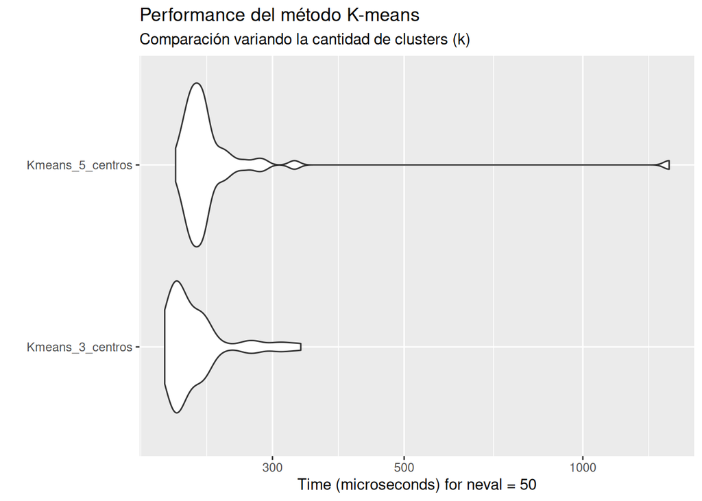

```r
# Medimos el rendimiento de kmeans con un dataset interno de R (iris)
comparativa_kmeans <- microbenchmark(
Kmeans_3_centros = kmeans(iris[, 1:4], centers = 3),
Kmeans_5_centros = kmeans(iris[, 1:4], centers = 5),
times = 50
)
# Graficamos los resultados de K-means
autoplot(comparativa_kmeans) +
labs(title = "Performance del método K-means",
subtitle = "Comparación variando la cantidad de clusters (k)",
y = "Tiempo de ejecución", x = "Configuración")
```